# Assignment 4

Author: Davis Muro

For CPSC 5610

Microsoft Stock Prediction

```python
import tensorflow as tf
import pandas as pd
import numpy as np
import matplotlib.pyplot as plt
from sklearn.preprocessing import MinMaxScaler
from sklearn.metrics import mean_absolute_error, mean_squared_error
from tensorflow.keras import activations
from tensorflow.keras.models import Sequential
from tensorflow.keras.layers import Dense, SimpleRNN, LSTM, GRU, Input, BatchNormalization, Layer
from tensorflow.keras.callbacks import EarlyStopping, ReduceLROnPlateau
from typing import Tuple, List
import matplotlib.dates as mdates
import os
```

```python
from google.colab import drive
drive.mount('/content/drive')
```

```python
np.random.seed(25)
tf.random.set_seed(25)
```

## Preprocessing

```python
df = pd.read_csv('data/MSFT.csv', parse_dates=['Date'], index_col='Date')

# Sort dataframe by `Date` (Ascending)
df.sort_index(inplace=True)

# Drop Adj Close
df.drop(columns=['Adj Close'], inplace=True)

df.head(5)
```

| Date | Open | High | Low | Close | Volume |
| --- | --- | --- | --- | --- | --- |
| 2016-11-07 | 59.779999 | 60.520000 | 59.779999 | 60.419998 | 31664800 |
| 2016-11-08 | 60.549999 | 60.779999 | 60.150002 | 60.470001 | 22935400 |
| 2016-11-09 | 60.000000 | 60.590000 | 59.200001 | 60.169998 | 49632500 |
| 2016-11-10 | 60.480000 | 60.490002 | 57.630001 | 58.700001 | 57822400 |
| 2016-11-11 | 58.230000 | 59.119999 | 58.009998 | 59.020000 | 38767800 |

```python
df['Open'].max(), df['High'].max(), df['Low'].max(), df['Close'].max(), df['Volume'].max()
```

```
(338.51001, 338.790009, 334.420013, 336.440002, 111242100)
```

```python
df.shape
```

```
(1259, 5)
```

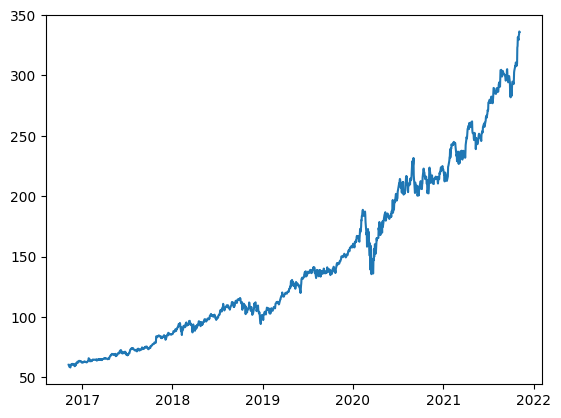

```python
plt.plot(df.index, df['Close'])
```

```python
scaler = MinMaxScaler()
volume_scaler = MinMaxScaler()
features = ['Open', 'High', 'Low', 'Close', 'Volume']

def scale_features(df):
  df = df.copy(deep=True)

  df[features[:4]] = scaler.fit_transform(df[features[:4]])
  df[features[4:]] = volume_scaler.fit_transform(df[features[4:]])

  return df

normalized = scale_features(df)
normalized.head(5)
```

| Date | Open | High | Low | Close | Volume |
| --- | --- | --- | --- | --- | --- |
| 2016-11-07 | 0.005530 | 0.005148 | 0.009021 | 0.008264 | 0.233481 |
| 2016-11-08 | 0.008277 | 0.006078 | 0.010356 | 0.008444 | 0.149396 |
| 2016-11-09 | 0.006315 | 0.005398 | 0.006928 | 0.007366 | 0.406553 |
| 2016-11-10 | 0.008028 | 0.005041 | 0.001263 | 0.002084 | 0.485441 |
| 2016-11-11 | 0.000000 | 0.000143 | 0.002634 | 0.003234 | 0.301900 |

```python
normalized['Open'].max(), normalized['High'].max(), normalized['Low'].max(), normalized['Close'].max(), normalized['Volume'].max()
```

```
(1.0, 1.0, 0.9999999999999999, 1.0, 1.0)
```

```python
normalized.shape
```

```
(1259, 5)
```

## Windowing

```python
def inverse_scale(predictions):
    prices_scaled = predictions[:, :4]
    volume_scaled = predictions[:, 4:]

    prices_unscaled = scaler.inverse_transform(prices_scaled)
    volume_unscaled = volume_scaler.inverse_transform(volume_scaled)

    # concatenate back into a single array (num_steps, 5)
    unscaled = np.concatenate([prices_unscaled, volume_unscaled], axis=1)
    return unscaled
```

```python
train_size = normalized.shape[0] * 80 // 100
test_size = normalized.shape[0] - train_size
dates_train = df.index[:train_size]
dates_val = df.index[train_size:]
train_size, test_size
```

```
(1007, 252)
```

```python
def window(df, n_steps, batch_size, shuffle=False):
    ds = tf.data.Dataset.from_tensor_slices(df)
    ds = ds.window(n_steps + 1, shift=1, drop_remainder=True)
    ds = ds.flat_map(lambda window: window.batch(n_steps + 1))
    ds = ds.map(lambda window: (window[:-1], window[-1]))
    if shuffle:
      ds = ds.shuffle(10000).batch(batch_size).prefetch(1)
    else:
      ds = ds.batch(batch_size).prefetch(1)
    return ds
```

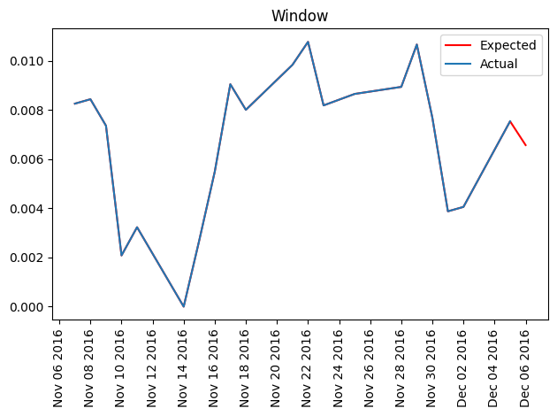

```
Num batches: 99
```

```python
timesteps = 20
batch_size = 10

train = window(normalized[:train_size], timesteps, batch_size)
for (X, y) in train.take(1):
  full_sequence = np.append(X[0, :, 3].numpy(), y[0, 3].numpy())
  plt.plot(dates_train[:21], full_sequence, label="Expected", color='red')
  plt.plot(dates_train[:20], X[0, :, 3].numpy(), label='Actual')
  plt.title("Window")
  plt.legend()
  plt.gca().xaxis.set_major_formatter(mdates.DateFormatter('%b %d %Y'))
  plt.gca().xaxis.set_major_locator(mdates.DayLocator(interval=2))
  plt.xticks(rotation=90)
  plt.tight_layout()
  plt.show()

train = window(normalized[:train_size], timesteps, batch_size, shuffle=True)
print("Num batches:", len(list(train)))
```

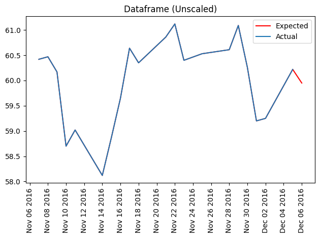

```python
plt.plot(dates_train[:21], df.iloc[:21, 3], label="Expected", color='red')
plt.plot(dates_train[:20], df.iloc[:20, 3], label="Actual")
plt.legend()
plt.title("Dataframe (Unscaled)")
plt.legend()
plt.gca().xaxis.set_major_formatter(mdates.DateFormatter('%b %d %Y'))
plt.gca().xaxis.set_major_locator(mdates.DayLocator(interval=2))
plt.xticks(rotation=90)
plt.tight_layout()
plt.show()
```

```python
test = window(normalized[train_size:], timesteps, batch_size, shuffle=True)
```

## Modelling

```python
class BatchNormSimpleRNN(Layer):
    def __init__(self, units, return_sequences=False, dropout=0.2, recurrent_dropout=0.2, activation='tanh', **kwargs):
        super().__init__(**kwargs)
        self.simple_rnn = SimpleRNN(
            units,
            activation=None,
            return_sequences=return_sequences,
            dropout=dropout,
            recurrent_dropout=recurrent_dropout,
            **kwargs
        )
        self.batch_norm = BatchNormalization()
        self.activation_fn = activations.get(activation)

    def call(self, inputs, training=None):
        x = self.simple_rnn(inputs, training=training)
        x = self.batch_norm(x, training=training)
        return self.activation_fn(x)
```

```python
def create_model(kind: str = "simple", input_shape: Tuple[int, int] = (timesteps, 5), neurons: int = 64):
  model = tf.keras.models.Sequential()
  model.add(Input(shape=input_shape))

  if kind == "simple":
    model.add(BatchNormSimpleRNN(neurons, return_sequences=False, dropout=0.2, recurrent_dropout=0.2))
  elif kind == "lstm":
    model.add(LSTM(neurons, return_sequences=False, dropout=0.2, recurrent_dropout=0.2))
  elif kind == "gru":
    model.add(GRU(neurons, return_sequences=False, dropout=0.2, recurrent_dropout=0.2))
  else:
    assert False, "Unsupported kind: " + kind

  model.add(Dense(32, activation="relu"))
  model.add(Dense(input_shape[1]))
  model.compile(loss="mse", optimizer="adam", metrics=["mae"])
  return model
```

```python
early_stopping = EarlyStopping(
    monitor='val_mae',
    patience=5,
    restore_best_weights=True
)

lr_scheduling = ReduceLROnPlateau(
    monitor='val_mae',
    factor=0.5,
    patience=2,
    min_lr=1e-6,
    verbose=1
)

epochs = 30
```

### Simple RNN

*Architecture*

Input: (timesteps, 5)

Layer 1: BatchNormSimpleRNN(64, return_sequences=False, dropout=0.2, recurrent_dropout=0.2)

Layer 2: Dense(32, activation='relu')

Output: Dense(5) → predicts [Open, High, Low, Close, Volume]

Loss: mse, Metric: mae

```python
simple_checkpoint_path = "drive/MyDrive/models/simple_cp.weights.h5"
checkpoint_dir = os.path.dirname(simple_checkpoint_path)

cp_callback = tf.keras.callbacks.ModelCheckpoint(filepath=simple_checkpoint_path,
                                                 save_weights_only=True,
                                                 monitor='val_mae',
                                                 mode='min',
                                                 save_best_only=True,
                                                 verbose=1)
```

```python
simple = create_model(kind="simple")
simple.summary()
```

```
Model: "sequential"
```

```
┏━━━━━━━━━━━━━━━━━━━━━━━━━━━━━━━━━┳━━━━━━━━━━━━━━━━━━━━━━━━┳━━━━━━━━━━━━━━━┓
┃ Layer (type)                    ┃ Output Shape           ┃       Param # ┃
┡━━━━━━━━━━━━━━━━━━━━━━━━━━━━━━━━━╇━━━━━━━━━━━━━━━━━━━━━━━━╇━━━━━━━━━━━━━━━┩
│ batch_norm_simple_rnn           │ (None, 64)             │         4,736 │
│ (BatchNormSimpleRNN)            │                        │               │
├─────────────────────────────────┼────────────────────────┼───────────────┤
│ dense (Dense)                   │ (None, 32)             │         2,080 │
├─────────────────────────────────┼────────────────────────┼───────────────┤
│ dense_1 (Dense)                 │ (None, 5)              │           165 │
└─────────────────────────────────┴────────────────────────┴───────────────┘
```

```
 Total params: 6,981 (27.27 KB)
```

```
 Trainable params: 6,853 (26.77 KB)
```

```
 Non-trainable params: 128 (512.00 B)
```

```python
simple.fit(train, epochs=epochs, validation_data=test, callbacks=[early_stopping, lr_scheduling, cp_callback])
```

```
     92/Unknown 6s 6ms/step - loss: 0.2181 - mae: 0.3495
```

```
Epoch 1: val_mae improved from inf to 0.44434, saving model to drive/MyDrive/models/simple_cp.weights.h5
99/99 ━━━━━━━━━━━━━━━━━━━━ 7s 14ms/step - loss: 0.2109 - mae: 0.3424 - val_loss: 0.2606 - val_mae: 0.4443 - learning_rate: 0.0010
93/99 ━━━━━━━━━━━━━━━━━━━━ 0s 6ms/step - loss: 0.0501 - mae: 0.1732
Epoch 2: val_mae did not improve from 0.44434
99/99 ━━━━━━━━━━━━━━━━━━━━ 2s 7ms/step - loss: 0.0499 - mae: 0.1728 - val_loss: 0.3041 - val_mae: 0.5085 - learning_rate: 0.0010
92/99 ━━━━━━━━━━━━━━━━━━━━ 0s 6ms/step - loss: 0.0356 - mae: 0.1462
Epoch 3: ReduceLROnPlateau reducing learning rate to 0.0005000000237487257.

Epoch 3: val_mae did not improve from 0.44434
99/99 ━━━━━━━━━━━━━━━━━━━━ 1s 7ms/step - loss: 0.0355 - mae: 0.1460 - val_loss: 0.3098 - val_mae: 0.5121 - learning_rate: 0.0010
97/99 ━━━━━━━━━━━━━━━━━━━━ 0s 6ms/step - loss: 0.0311 - mae: 0.1351
Epoch 4: val_mae improved from 0.44434 to 0.42009, saving model to drive/MyDrive/models/simple_cp.weights.h5
99/99 ━━━━━━━━━━━━━━━━━━━━ 1s 8ms/step - loss: 0.0311 - mae: 0.1350 - val_loss: 0.2098 - val_mae: 0.4201 - learning_rate: 5.0000e-04
91/99 ━━━━━━━━━━━━━━━━━━━━ 0s 6ms/step - loss: 0.0279 - mae: 0.1265
Epoch 5: val_mae did not improve from 0.42009
99/99 ━━━━━━━━━━━━━━━━━━━━ 1s 7ms/step - loss: 0.0278 - mae: 0.1263 - val_loss: 0.2358 - val_mae: 0.4449 - learning_rate: 5.0000e-04
92/99 ━━━━━━━━━━━━━━━━━━━━ 0s 6ms/step - loss: 0.0255 - mae: 0.1233
Epoch 6: val_mae improved from 0.42009 to 0.40580, saving model to drive/MyDrive/models/simple_cp.weights.h5
99/99 ━━━━━━━━━━━━━━━━━━━━ 1s 8ms/step - loss: 0.0255 - mae: 0.1234 - val_loss: 0.2005 - val_mae: 0.4058 - learning_rate: 5.0000e-04
98/99 ━━━━━━━━━━━━━━━━━━━━ 0s 9ms/step - loss: 0.0247 - mae: 0.1214
Epoch 7: val_mae improved from 0.40580 to 0.39061, saving model to drive/MyDrive/models/simple_cp.weights.h5
99/99 ━━━━━━━━━━━━━━━━━━━━ 2s 11ms/step - loss: 0.0247 - mae: 0.1213 - val_loss: 0.1879 - val_mae: 0.3906 - learning_rate: 5.0000e-04
99/99 ━━━━━━━━━━━━━━━━━━━━ 0s 9ms/step - loss: 0.0240 - mae: 0.1194
Epoch 8: val_mae did not improve from 0.39061
99/99 ━━━━━━━━━━━━━━━━━━━━ 1s 11ms/step - loss: 0.0240 - mae: 0.1194 - val_loss: 0.1920 - val_mae: 0.3967 - learning_rate: 5.0000e-04
99/99 ━━━━━━━━━━━━━━━━━━━━ 0s 7ms/step - loss: 0.0206 - mae: 0.1095
Epoch 9: ReduceLROnPlateau reducing learning rate to 0.0002500000118743628.

Epoch 9: val_mae did not improve from 0.39061
99/99 ━━━━━━━━━━━━━━━━━━━━ 2s 8ms/step - loss: 0.0206 - mae: 0.1095 - val_loss: 0.1861 - val_mae: 0.3916 - learning_rate: 5.0000e-04
97/99 ━━━━━━━━━━━━━━━━━━━━ 0s 6ms/step - loss: 0.0214 - mae: 0.1126
Epoch 10: val_mae did not improve from 0.39061
99/99 ━━━━━━━━━━━━━━━━━━━━ 1s 8ms/step - loss: 0.0213 - mae: 0.1125 - val_loss: 0.1960 - val_mae: 0.3988 - learning_rate: 2.5000e-04
98/99 ━━━━━━━━━━━━━━━━━━━━ 0s 6ms/step - loss: 0.0205 - mae: 0.1090
Epoch 11: ReduceLROnPlateau reducing learning rate to 0.0001250000059371814.

Epoch 11: val_mae did not improve from 0.39061
99/99 ━━━━━━━━━━━━━━━━━━━━ 1s 7ms/step - loss: 0.0205 - mae: 0.1090 - val_loss: 0.1902 - val_mae: 0.3933 - learning_rate: 2.5000e-04
97/99 ━━━━━━━━━━━━━━━━━━━━ 0s 6ms/step - loss: 0.0207 - mae: 0.1098
Epoch 12: val_mae improved from 0.39061 to 0.38664, saving model to drive/MyDrive/models/simple_cp.weights.h5
```

[output cut: 14 more lines]

```
Epoch 17: ReduceLROnPlateau reducing learning rate to 6.25000029685907e-05.

Epoch 17: val_mae did not improve from 0.38110
99/99 ━━━━━━━━━━━━━━━━━━━━ 5s 47ms/step - loss: 0.0187 - mae: 0.1059 - val_loss: 0.1892 - val_mae: 0.3921 - learning_rate: 1.2500e-04
95/99 ━━━━━━━━━━━━━━━━━━━━ 0s 10ms/step - loss: 0.0192 - mae: 0.1075
Epoch 18: val_mae did not improve from 0.38110
99/99 ━━━━━━━━━━━━━━━━━━━━ 2s 11ms/step - loss: 0.0192 - mae: 0.1073 - val_loss: 0.1874 - val_mae: 0.3902 - learning_rate: 6.2500e-05
98/99 ━━━━━━━━━━━━━━━━━━━━ 0s 9ms/step - loss: 0.0183 - mae: 0.1038
Epoch 19: ReduceLROnPlateau reducing learning rate to 3.125000148429535e-05.

Epoch 19: val_mae did not improve from 0.38110
99/99 ━━━━━━━━━━━━━━━━━━━━ 1s 11ms/step - loss: 0.0183 - mae: 0.1038 - val_loss: 0.1849 - val_mae: 0.3876 - learning_rate: 6.2500e-05
96/99 ━━━━━━━━━━━━━━━━━━━━ 0s 10ms/step - loss: 0.0187 - mae: 0.1054
Epoch 20: val_mae did not improve from 0.38110
99/99 ━━━━━━━━━━━━━━━━━━━━ 1s 12ms/step - loss: 0.0187 - mae: 0.1054 - val_loss: 0.1896 - val_mae: 0.3923 - learning_rate: 3.1250e-05
```

```
<keras.src.callbacks.history.History at 0x7e9f2b077390>
```

```python
result = pd.DataFrame(simple.history.history)
result.head()
```

|  | loss | mae | val_loss | val_mae | learning_rate |
| --- | --- | --- | --- | --- | --- |
| 0 | 0.126205 | 0.259030 | 0.260602 | 0.444345 | 0.0010 |
| 1 | 0.046794 | 0.167244 | 0.304089 | 0.508518 | 0.0010 |
| 2 | 0.034311 | 0.142799 | 0.309802 | 0.512131 | 0.0010 |
| 3 | 0.029034 | 0.130276 | 0.209829 | 0.420090 | 0.0005 |
| 4 | 0.026407 | 0.124128 | 0.235819 | 0.444879 | 0.0005 |

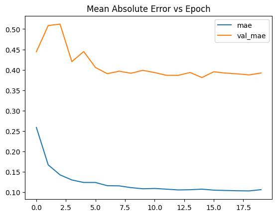

```python
result[['mae', 'val_mae']].plot(title="Mean Absolute Error vs Epoch")
```

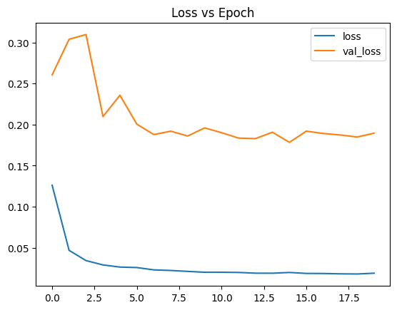

```python
result[['loss','val_loss']].plot(title="Loss vs Epoch")
```

### GRU Model

*Architecture*

Input: (timesteps, 5)

Layer 1: GRU(64, return_sequences=False, dropout=0.2, recurrent_dropout=0.2)

Layer 2: Dense(32, activation='relu')

Output: Dense(5)

Loss: mse, Metric: mae

```python
gru_checkpoint_path = "drive/MyDrive/models/gru_cp.weights.h5"
cp_callback = tf.keras.callbacks.ModelCheckpoint(filepath=gru_checkpoint_path,
                                                 save_weights_only=True,
                                                 monitor='val_mae',
                                                 mode='min',
                                                 save_best_only=True,
                                                 verbose=1)
```

```python
gru = create_model(kind="gru")
gru.summary()
```

```
Model: "sequential_1"
```

```
┏━━━━━━━━━━━━━━━━━━━━━━━━━━━━━━━━━┳━━━━━━━━━━━━━━━━━━━━━━━━┳━━━━━━━━━━━━━━━┓
┃ Layer (type)                    ┃ Output Shape           ┃       Param # ┃
┡━━━━━━━━━━━━━━━━━━━━━━━━━━━━━━━━━╇━━━━━━━━━━━━━━━━━━━━━━━━╇━━━━━━━━━━━━━━━┩
│ gru (GRU)                       │ (None, 64)             │        13,632 │
├─────────────────────────────────┼────────────────────────┼───────────────┤
│ dense_2 (Dense)                 │ (None, 32)             │         2,080 │
├─────────────────────────────────┼────────────────────────┼───────────────┤
│ dense_3 (Dense)                 │ (None, 5)              │           165 │
└─────────────────────────────────┴────────────────────────┴───────────────┘
```

```
 Total params: 15,877 (62.02 KB)
```

```
 Trainable params: 15,877 (62.02 KB)
```

```
 Non-trainable params: 0 (0.00 B)
```

```python
gru.fit(train, epochs=epochs, validation_data=test, callbacks=[early_stopping, lr_scheduling, cp_callback])
```

```
     99/Unknown 7s 25ms/step - loss: 0.0162 - mae: 0.0844
```

```
Epoch 1: val_mae improved from inf to 0.15214, saving model to drive/MyDrive/models/gru_cp.weights.h5
99/99 ━━━━━━━━━━━━━━━━━━━━ 8s 37ms/step - loss: 0.0162 - mae: 0.0842 - val_loss: 0.0258 - val_mae: 0.1521 - learning_rate: 0.0010
96/99 ━━━━━━━━━━━━━━━━━━━━ 0s 16ms/step - loss: 0.0048 - mae: 0.0460
Epoch 2: val_mae improved from 0.15214 to 0.14247, saving model to drive/MyDrive/models/gru_cp.weights.h5
99/99 ━━━━━━━━━━━━━━━━━━━━ 3s 18ms/step - loss: 0.0048 - mae: 0.0458 - val_loss: 0.0231 - val_mae: 0.1425 - learning_rate: 0.0010
99/99 ━━━━━━━━━━━━━━━━━━━━ 0s 15ms/step - loss: 0.0040 - mae: 0.0386
Epoch 3: val_mae did not improve from 0.14247
99/99 ━━━━━━━━━━━━━━━━━━━━ 2s 17ms/step - loss: 0.0040 - mae: 0.0386 - val_loss: 0.0315 - val_mae: 0.1669 - learning_rate: 0.0010
96/99 ━━━━━━━━━━━━━━━━━━━━ 0s 16ms/step - loss: 0.0038 - mae: 0.0343
Epoch 4: val_mae improved from 0.14247 to 0.14091, saving model to drive/MyDrive/models/gru_cp.weights.h5
99/99 ━━━━━━━━━━━━━━━━━━━━ 2s 18ms/step - loss: 0.0038 - mae: 0.0342 - val_loss: 0.0218 - val_mae: 0.1409 - learning_rate: 0.0010
99/99 ━━━━━━━━━━━━━━━━━━━━ 0s 15ms/step - loss: 0.0031 - mae: 0.0304
Epoch 5: val_mae did not improve from 0.14091
99/99 ━━━━━━━━━━━━━━━━━━━━ 2s 17ms/step - loss: 0.0031 - mae: 0.0303 - val_loss: 0.0234 - val_mae: 0.1449 - learning_rate: 0.0010
98/99 ━━━━━━━━━━━━━━━━━━━━ 0s 15ms/step - loss: 0.0032 - mae: 0.0273
Epoch 6: ReduceLROnPlateau reducing learning rate to 0.0005000000237487257.

Epoch 6: val_mae did not improve from 0.14091
99/99 ━━━━━━━━━━━━━━━━━━━━ 2s 17ms/step - loss: 0.0032 - mae: 0.0274 - val_loss: 0.0252 - val_mae: 0.1531 - learning_rate: 0.0010
98/99 ━━━━━━━━━━━━━━━━━━━━ 0s 28ms/step - loss: 0.0025 - mae: 0.0258
Epoch 7: val_mae did not improve from 0.14091
99/99 ━━━━━━━━━━━━━━━━━━━━ 5s 42ms/step - loss: 0.0025 - mae: 0.0258 - val_loss: 0.0227 - val_mae: 0.1429 - learning_rate: 5.0000e-04
99/99 ━━━━━━━━━━━━━━━━━━━━ 0s 16ms/step - loss: 0.0026 - mae: 0.0258
Epoch 8: val_mae improved from 0.14091 to 0.14058, saving model to drive/MyDrive/models/gru_cp.weights.h5
99/99 ━━━━━━━━━━━━━━━━━━━━ 2s 20ms/step - loss: 0.0026 - mae: 0.0258 - val_loss: 0.0221 - val_mae: 0.1406 - learning_rate: 5.0000e-04
97/99 ━━━━━━━━━━━━━━━━━━━━ 0s 16ms/step - loss: 0.0028 - mae: 0.0265
Epoch 9: val_mae did not improve from 0.14058
99/99 ━━━━━━━━━━━━━━━━━━━━ 2s 17ms/step - loss: 0.0028 - mae: 0.0265 - val_loss: 0.0221 - val_mae: 0.1413 - learning_rate: 5.0000e-04
99/99 ━━━━━━━━━━━━━━━━━━━━ 0s 16ms/step - loss: 0.0027 - mae: 0.0257
Epoch 10: ReduceLROnPlateau reducing learning rate to 0.0002500000118743628.

Epoch 10: val_mae did not improve from 0.14058
99/99 ━━━━━━━━━━━━━━━━━━━━ 2s 17ms/step - loss: 0.0027 - mae: 0.0257 - val_loss: 0.0229 - val_mae: 0.1413 - learning_rate: 5.0000e-04
99/99 ━━━━━━━━━━━━━━━━━━━━ 0s 16ms/step - loss: 0.0023 - mae: 0.0235
Epoch 11: val_mae improved from 0.14058 to 0.14026, saving model to drive/MyDrive/models/gru_cp.weights.h5
99/99 ━━━━━━━━━━━━━━━━━━━━ 2s 18ms/step - loss: 0.0023 - mae: 0.0235 - val_loss: 0.0220 - val_mae: 0.1403 - learning_rate: 2.5000e-04
98/99 ━━━━━━━━━━━━━━━━━━━━ 0s 20ms/step - loss: 0.0024 - mae: 0.0238
Epoch 12: val_mae did not improve from 0.14026
99/99 ━━━━━━━━━━━━━━━━━━━━ 2s 22ms/step - loss: 0.0024 - mae: 0.0238 - val_loss: 0.0237 - val_mae: 0.1467 - learning_rate: 2.5000e-04
98/99 ━━━━━━━━━━━━━━━━━━━━ 0s 28ms/step - loss: 0.0023 - mae: 0.0228
Epoch 13: val_mae improved from 0.14026 to 0.12985, saving model to drive/MyDrive/models/gru_cp.weights.h5
99/99 ━━━━━━━━━━━━━━━━━━━━ 5s 48ms/step - loss: 0.0023 - mae: 0.0228 - val_loss: 0.0190 - val_mae: 0.1299 - learning_rate: 2.5000e-04
97/99 ━━━━━━━━━━━━━━━━━━━━ 0s 16ms/step - loss: 0.0027 - mae: 0.0242
Epoch 14: val_mae did not improve from 0.12985
99/99 ━━━━━━━━━━━━━━━━━━━━ 2s 18ms/step - loss: 0.0027 - mae: 0.0242 - val_loss: 0.0207 - val_mae: 0.1351 - learning_rate: 2.5000e-04
98/99 ━━━━━━━━━━━━━━━━━━━━ 0s 16ms/step - loss: 0.0022 - mae: 0.0225
Epoch 15: ReduceLROnPlateau reducing learning rate to 0.0001250000059371814.

Epoch 15: val_mae did not improve from 0.12985
99/99 ━━━━━━━━━━━━━━━━━━━━ 2s 18ms/step - loss: 0.0022 - mae: 0.0225 - val_loss: 0.0216 - val_mae: 0.1395 - learning_rate: 2.5000e-04
99/99 ━━━━━━━━━━━━━━━━━━━━ 0s 16ms/step - loss: 0.0025 - mae: 0.0240
Epoch 16: val_mae did not improve from 0.12985
99/99 ━━━━━━━━━━━━━━━━━━━━ 2s 17ms/step - loss: 0.0025 - mae: 0.0240 - val_loss: 0.0214 - val_mae: 0.1396 - learning_rate: 1.2500e-04
99/99 ━━━━━━━━━━━━━━━━━━━━ 0s 16ms/step - loss: 0.0022 - mae: 0.0226
Epoch 17: ReduceLROnPlateau reducing learning rate to 6.25000029685907e-05.

Epoch 17: val_mae did not improve from 0.12985
99/99 ━━━━━━━━━━━━━━━━━━━━ 2s 17ms/step - loss: 0.0022 - mae: 0.0226 - val_loss: 0.0207 - val_mae: 0.1363 - learning_rate: 1.2500e-04
98/99 ━━━━━━━━━━━━━━━━━━━━ 0s 24ms/step - loss: 0.0025 - mae: 0.0238
Epoch 18: val_mae did not improve from 0.12985
99/99 ━━━━━━━━━━━━━━━━━━━━ 5s 51ms/step - loss: 0.0025 - mae: 0.0238 - val_loss: 0.0214 - val_mae: 0.1389 - learning_rate: 6.2500e-05
```

```
<keras.src.callbacks.history.History at 0x7e9f282ff390>
```

```python
result = pd.DataFrame(gru.history.history)
result.head()
```

|  | loss | mae | val_loss | val_mae | learning_rate |
| --- | --- | --- | --- | --- | --- |
| 0 | 0.008922 | 0.063031 | 0.025784 | 0.152142 | 0.001 |
| 1 | 0.004402 | 0.042402 | 0.023143 | 0.142466 | 0.001 |
| 2 | 0.003603 | 0.036953 | 0.031474 | 0.166888 | 0.001 |
| 3 | 0.003421 | 0.032195 | 0.021790 | 0.140911 | 0.001 |
| 4 | 0.002946 | 0.029103 | 0.023357 | 0.144893 | 0.001 |

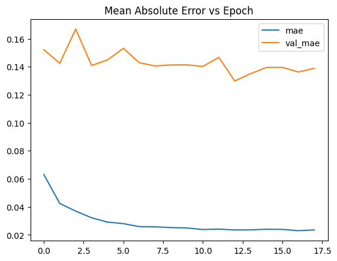

```python
result[['mae', 'val_mae']].plot(title="Mean Absolute Error vs Epoch")
```

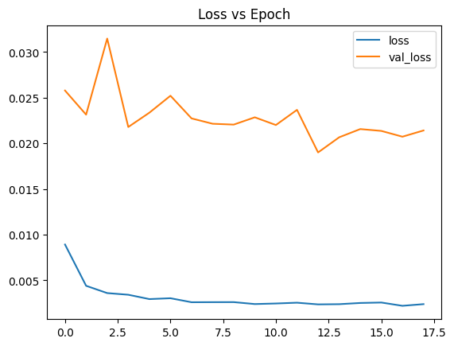

```python
result[['loss','val_loss']].plot(title="Loss vs Epoch")
```

### LSTM

*Architecture*

Input: (timesteps, 5)

Layer 1: LSTM(64, return_sequences=False, dropout=0.2, recurrent_dropout=0.2)

Layer 2: Dense(32, activation='relu')

Output: Dense(5)

Loss: mse, Metric: mae

```python
lstm_checkpoint_path = "drive/MyDrive/models/lstm_cp.weights.h5"
cp_callback = tf.keras.callbacks.ModelCheckpoint(filepath=lstm_checkpoint_path,
                                                 save_weights_only=True,
                                                 monitor='val_mae',
                                                 mode='min',
                                                 save_best_only=True,
                                                 verbose=1)
```

```python
lstm = create_model(kind="lstm")
lstm.summary()
```

```
Model: "sequential_2"
```

```
┏━━━━━━━━━━━━━━━━━━━━━━━━━━━━━━━━━┳━━━━━━━━━━━━━━━━━━━━━━━━┳━━━━━━━━━━━━━━━┓
┃ Layer (type)                    ┃ Output Shape           ┃       Param # ┃
┡━━━━━━━━━━━━━━━━━━━━━━━━━━━━━━━━━╇━━━━━━━━━━━━━━━━━━━━━━━━╇━━━━━━━━━━━━━━━┩
│ lstm (LSTM)                     │ (None, 64)             │        17,920 │
├─────────────────────────────────┼────────────────────────┼───────────────┤
│ dense_4 (Dense)                 │ (None, 32)             │         2,080 │
├─────────────────────────────────┼────────────────────────┼───────────────┤
│ dense_5 (Dense)                 │ (None, 5)              │           165 │
└─────────────────────────────────┴────────────────────────┴───────────────┘
```

```
 Total params: 20,165 (78.77 KB)
```

```
 Trainable params: 20,165 (78.77 KB)
```

```
 Non-trainable params: 0 (0.00 B)
```

```python
lstm.fit(train, epochs=epochs, validation_data=test, callbacks=[early_stopping, lr_scheduling, cp_callback])
```

```
     97/Unknown 6s 19ms/step - loss: 0.0239 - mae: 0.1044
```

```
Epoch 1: val_mae improved from inf to 0.09217, saving model to drive/MyDrive/models/lstm_cp.weights.h5
99/99 ━━━━━━━━━━━━━━━━━━━━ 7s 27ms/step - loss: 0.0235 - mae: 0.1034 - val_loss: 0.0116 - val_mae: 0.0922 - learning_rate: 0.0010
99/99 ━━━━━━━━━━━━━━━━━━━━ 0s 26ms/step - loss: 0.0056 - mae: 0.0516
Epoch 2: val_mae did not improve from 0.09217
99/99 ━━━━━━━━━━━━━━━━━━━━ 5s 27ms/step - loss: 0.0056 - mae: 0.0516 - val_loss: 0.0209 - val_mae: 0.1341 - learning_rate: 0.0010
99/99 ━━━━━━━━━━━━━━━━━━━━ 0s 18ms/step - loss: 0.0051 - mae: 0.0473
Epoch 3: ReduceLROnPlateau reducing learning rate to 0.0005000000237487257.

Epoch 3: val_mae did not improve from 0.09217
99/99 ━━━━━━━━━━━━━━━━━━━━ 2s 20ms/step - loss: 0.0051 - mae: 0.0473 - val_loss: 0.0197 - val_mae: 0.1272 - learning_rate: 0.0010
99/99 ━━━━━━━━━━━━━━━━━━━━ 0s 18ms/step - loss: 0.0053 - mae: 0.0493
Epoch 4: val_mae did not improve from 0.09217
99/99 ━━━━━━━━━━━━━━━━━━━━ 2s 20ms/step - loss: 0.0053 - mae: 0.0493 - val_loss: 0.0185 - val_mae: 0.1242 - learning_rate: 5.0000e-04
99/99 ━━━━━━━━━━━━━━━━━━━━ 0s 33ms/step - loss: 0.0046 - mae: 0.0436
Epoch 5: ReduceLROnPlateau reducing learning rate to 0.0002500000118743628.

Epoch 5: val_mae did not improve from 0.09217
99/99 ━━━━━━━━━━━━━━━━━━━━ 5s 52ms/step - loss: 0.0046 - mae: 0.0436 - val_loss: 0.0243 - val_mae: 0.1429 - learning_rate: 5.0000e-04
99/99 ━━━━━━━━━━━━━━━━━━━━ 0s 19ms/step - loss: 0.0031 - mae: 0.0363
Epoch 6: val_mae did not improve from 0.09217
99/99 ━━━━━━━━━━━━━━━━━━━━ 7s 20ms/step - loss: 0.0031 - mae: 0.0364 - val_loss: 0.0192 - val_mae: 0.1275 - learning_rate: 2.5000e-04
```

```
<keras.src.callbacks.history.History at 0x7e9f22147390>
```

```python
result = pd.DataFrame(lstm.history.history)
result.head()
```

|  | loss | mae | val_loss | val_mae | learning_rate |
| --- | --- | --- | --- | --- | --- |
| 0 | 0.011825 | 0.071295 | 0.011577 | 0.092166 | 0.0010 |
| 1 | 0.005449 | 0.050669 | 0.020913 | 0.134085 | 0.0010 |
| 2 | 0.004929 | 0.047438 | 0.019746 | 0.127177 | 0.0010 |
| 3 | 0.004797 | 0.045675 | 0.018496 | 0.124237 | 0.0005 |
| 4 | 0.004366 | 0.041950 | 0.024307 | 0.142930 | 0.0005 |

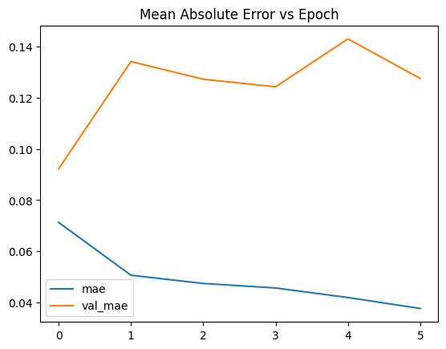

```python
result[['mae', 'val_mae']].plot(title="Mean Absolute Error vs Epoch")
```

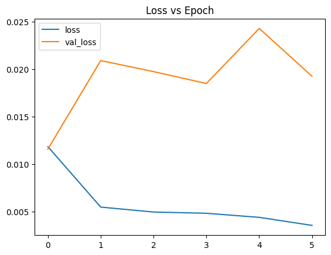

```python
result[['loss','val_loss']].plot(title="Loss vs Epoch")
```

## Evaluation

```python
def predict_range(model, start_date, days):
  end_idx = df.index.get_loc(start_date)
  input = df.iloc[end_idx - timesteps:end_idx]

  input = scale_features(input) # (20, 5)
  input = np.expand_dims(input, axis=0) # (1, 20, 5)

  predictions = []
  for _ in days:
    pred = model.predict(input)
    predictions.append(inverse_scale(pred)[0])
    input = np.concatenate([input[:, 1:, :], np.expand_dims(pred, axis=1)], axis=1)

  frame = pd.DataFrame(predictions, columns=df.columns, index=days)
  return frame
```

```python
def prediction_plot_feature(feature, predictions, pred_dates):
  plt.plot(pred_dates[1:], predictions[feature][1:], label="Predicted", linestyle="--")
  plt.title(f"{feature} - Predicted (11/08/2021 - 11/19/2021)")
  plt.legend()
  plt.gca().xaxis.set_major_formatter(mdates.DateFormatter('%b %d %Y'))
  plt.gca().xaxis.set_major_locator(mdates.DayLocator(interval=1))
  plt.xticks(rotation=90)
  plt.show()

def actual_vs_pred_plot_feature(feature, actual_data, predictions, pred_dates):
  plt.plot(pred_dates, actual_data[[feature]], label="Actual")
  plt.plot(pred_dates, predictions[[feature]], label="Predicted")
  plt.legend()
  plt.title(f"Actual vs Predicted ({feature})")
  plt.legend()
  plt.gca().xaxis.set_major_formatter(mdates.DateFormatter('%b %d %Y'))
  plt.gca().xaxis.set_major_locator(mdates.DayLocator(interval=2))
  plt.xticks(rotation=90)
  plt.show()
```

```python
def evaluate_predictions(actual, pred, features):
    results = {}
    for feature in features:
      mae = mean_absolute_error(actual[[feature]], pred[[feature]])
      mse = mean_squared_error(actual[[feature]], pred[[feature]])
      results[feature] = {'MAE': mae, 'MSE': mse}
    return results
```

```python
def load_latest_checkpoint(model):
    return os.path.join("models", f"{model}_cp.weights.h5")

simple = create_model("simple")
gru = create_model("gru")
lstm = create_model("lstm")

simple.load_weights(load_latest_checkpoint("simple"))
gru.load_weights(load_latest_checkpoint("gru"))
lstm.load_weights(load_latest_checkpoint("lstm"))
```

```python
simple.summary()
```

```
Model: "sequential_3"
```

```
┏━━━━━━━━━━━━━━━━━━━━━━━━━━━━━━━━━┳━━━━━━━━━━━━━━━━━━━━━━━━┳━━━━━━━━━━━━━━━┓
┃ Layer (type)                    ┃ Output Shape           ┃       Param # ┃
┡━━━━━━━━━━━━━━━━━━━━━━━━━━━━━━━━━╇━━━━━━━━━━━━━━━━━━━━━━━━╇━━━━━━━━━━━━━━━┩
│ batch_norm_simple_rnn_1         │ (None, 64)             │         4,736 │
│ (BatchNormSimpleRNN)            │                        │               │
├─────────────────────────────────┼────────────────────────┼───────────────┤
│ dense_6 (Dense)                 │ (None, 32)             │         2,080 │
├─────────────────────────────────┼────────────────────────┼───────────────┤
│ dense_7 (Dense)                 │ (None, 5)              │           165 │
└─────────────────────────────────┴────────────────────────┴───────────────┘
```

```
 Total params: 6,981 (27.27 KB)
```

```
 Trainable params: 6,853 (26.77 KB)
```

```
 Non-trainable params: 128 (512.00 B)
```

```python
gru.summary()
```

```
Model: "sequential_4"
```

```
┏━━━━━━━━━━━━━━━━━━━━━━━━━━━━━━━━━┳━━━━━━━━━━━━━━━━━━━━━━━━┳━━━━━━━━━━━━━━━┓
┃ Layer (type)                    ┃ Output Shape           ┃       Param # ┃
┡━━━━━━━━━━━━━━━━━━━━━━━━━━━━━━━━━╇━━━━━━━━━━━━━━━━━━━━━━━━╇━━━━━━━━━━━━━━━┩
│ gru_1 (GRU)                     │ (None, 64)             │        13,632 │
├─────────────────────────────────┼────────────────────────┼───────────────┤
│ dense_8 (Dense)                 │ (None, 32)             │         2,080 │
├─────────────────────────────────┼────────────────────────┼───────────────┤
│ dense_9 (Dense)                 │ (None, 5)              │           165 │
└─────────────────────────────────┴────────────────────────┴───────────────┘
```

```
 Total params: 15,877 (62.02 KB)
```

```
 Trainable params: 15,877 (62.02 KB)
```

```
 Non-trainable params: 0 (0.00 B)
```

```python
lstm.summary()
```

```
Model: "sequential_5"
```

```
┏━━━━━━━━━━━━━━━━━━━━━━━━━━━━━━━━━┳━━━━━━━━━━━━━━━━━━━━━━━━┳━━━━━━━━━━━━━━━┓
┃ Layer (type)                    ┃ Output Shape           ┃       Param # ┃
┡━━━━━━━━━━━━━━━━━━━━━━━━━━━━━━━━━╇━━━━━━━━━━━━━━━━━━━━━━━━╇━━━━━━━━━━━━━━━┩
│ lstm_1 (LSTM)                   │ (None, 64)             │        17,920 │
├─────────────────────────────────┼────────────────────────┼───────────────┤
│ dense_10 (Dense)                │ (None, 32)             │         2,080 │
├─────────────────────────────────┼────────────────────────┼───────────────┤
│ dense_11 (Dense)                │ (None, 5)              │           165 │
└─────────────────────────────────┴────────────────────────┴───────────────┘
```

```
 Total params: 20,165 (78.77 KB)
```

```
 Trainable params: 20,165 (78.77 KB)
```

```
 Non-trainable params: 0 (0.00 B)
```

#### Simple RNN

```python
pred_dates = dates_val[:21]
actual_data = df.loc[pred_dates]
predictions = predict_range(simple, pred_dates[0], pred_dates)
```

```
1/1 ━━━━━━━━━━━━━━━━━━━━ 0s 251ms/step
1/1 ━━━━━━━━━━━━━━━━━━━━ 0s 39ms/step
1/1 ━━━━━━━━━━━━━━━━━━━━ 0s 41ms/step
1/1 ━━━━━━━━━━━━━━━━━━━━ 0s 49ms/step
1/1 ━━━━━━━━━━━━━━━━━━━━ 0s 64ms/step
1/1 ━━━━━━━━━━━━━━━━━━━━ 0s 142ms/step
1/1 ━━━━━━━━━━━━━━━━━━━━ 0s 171ms/step
1/1 ━━━━━━━━━━━━━━━━━━━━ 0s 68ms/step
1/1 ━━━━━━━━━━━━━━━━━━━━ 0s 134ms/step
1/1 ━━━━━━━━━━━━━━━━━━━━ 0s 93ms/step
1/1 ━━━━━━━━━━━━━━━━━━━━ 0s 83ms/step
1/1 ━━━━━━━━━━━━━━━━━━━━ 0s 84ms/step
1/1 ━━━━━━━━━━━━━━━━━━━━ 0s 109ms/step
1/1 ━━━━━━━━━━━━━━━━━━━━ 0s 51ms/step
1/1 ━━━━━━━━━━━━━━━━━━━━ 0s 42ms/step
1/1 ━━━━━━━━━━━━━━━━━━━━ 0s 38ms/step
1/1 ━━━━━━━━━━━━━━━━━━━━ 0s 40ms/step
1/1 ━━━━━━━━━━━━━━━━━━━━ 0s 43ms/step
1/1 ━━━━━━━━━━━━━━━━━━━━ 0s 38ms/step
1/1 ━━━━━━━━━━━━━━━━━━━━ 0s 39ms/step
1/1 ━━━━━━━━━━━━━━━━━━━━ 0s 39ms/step
```

```python
evaluate_predictions(actual_data, predictions, df.columns)
```

```
{'Open': {'MAE': 6.86752905138579, 'MSE': 55.55770119412885},
 'High': {'MAE': 8.076581627976193, 'MSE': 74.2945963690422},
 'Low': {'MAE': 7.708222960518973, 'MSE': 64.80033693955909},
 'Close': {'MAE': 7.433672971400669, 'MSE': 62.644769512415756},
 'Volume': {'MAE': 4693172.761904762, 'MSE': 52809407835678.86}}
```

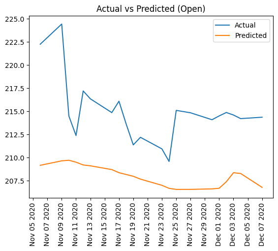

```python
actual_vs_pred_plot_feature('Open', actual_data, predictions, pred_dates)
```

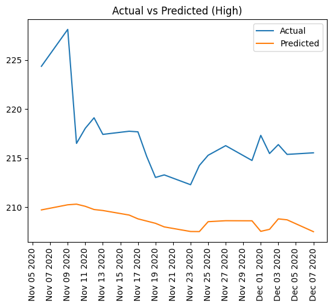

```python
actual_vs_pred_plot_feature('High', actual_data, predictions, pred_dates)
```

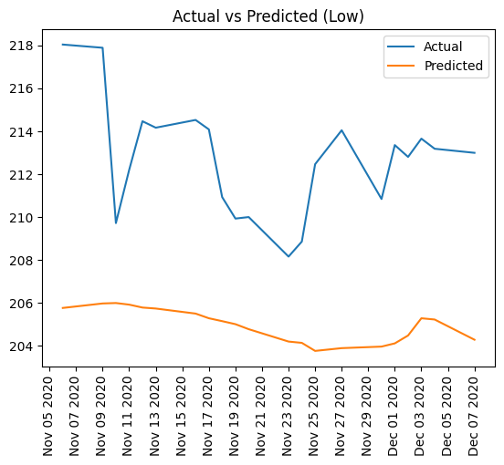

```python
actual_vs_pred_plot_feature('Low', actual_data, predictions, pred_dates)
```

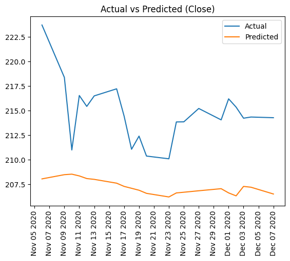

```python
actual_vs_pred_plot_feature('Close', actual_data, predictions, pred_dates)
```

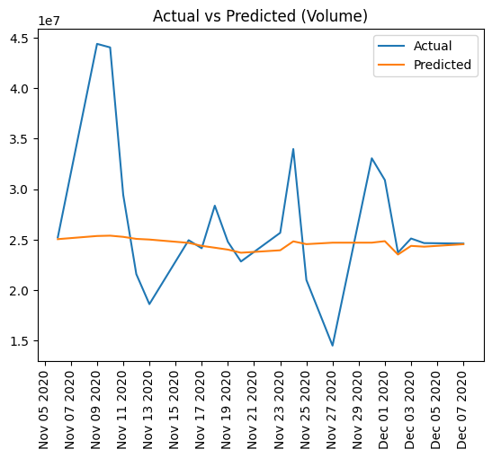

```python
actual_vs_pred_plot_feature('Volume', actual_data, predictions, pred_dates)
```

```python
# Predict all 5 columns for the 10 business days between 11/08/2021 and 11/19/2021
pred_dates = pd.bdate_range(start=df.index.max(), end="2021-11-19")
predictions = predict_range(simple, df.index.max(), pred_dates)
```

```
1/1 ━━━━━━━━━━━━━━━━━━━━ 0s 55ms/step
1/1 ━━━━━━━━━━━━━━━━━━━━ 0s 67ms/step
1/1 ━━━━━━━━━━━━━━━━━━━━ 0s 54ms/step
1/1 ━━━━━━━━━━━━━━━━━━━━ 0s 61ms/step
1/1 ━━━━━━━━━━━━━━━━━━━━ 0s 53ms/step
1/1 ━━━━━━━━━━━━━━━━━━━━ 0s 55ms/step
1/1 ━━━━━━━━━━━━━━━━━━━━ 0s 58ms/step
1/1 ━━━━━━━━━━━━━━━━━━━━ 0s 42ms/step
1/1 ━━━━━━━━━━━━━━━━━━━━ 0s 45ms/step
1/1 ━━━━━━━━━━━━━━━━━━━━ 0s 40ms/step
1/1 ━━━━━━━━━━━━━━━━━━━━ 0s 40ms/step
```

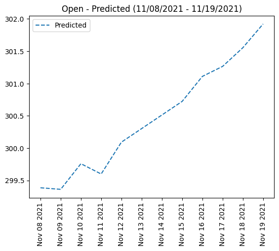

```python
prediction_plot_feature('Open', predictions, pred_dates)
```

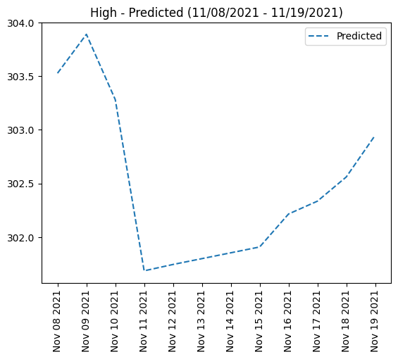

```python
prediction_plot_feature('High', predictions, pred_dates)
```

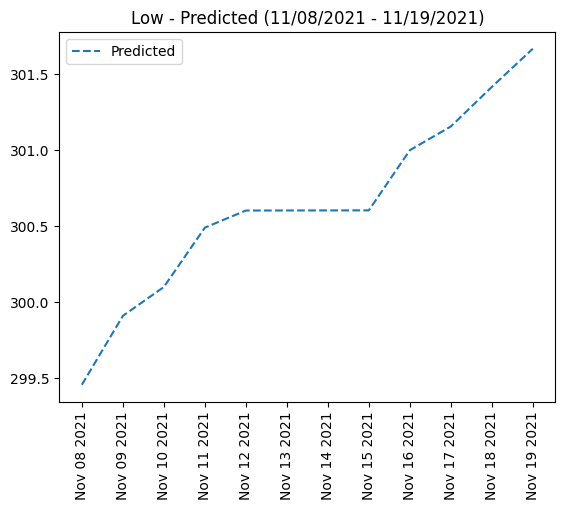

```python
prediction_plot_feature('Low', predictions, pred_dates)
```

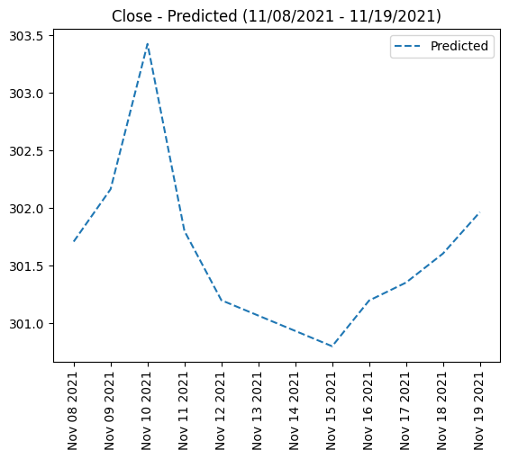

```python
prediction_plot_feature('Close', predictions, pred_dates)
```

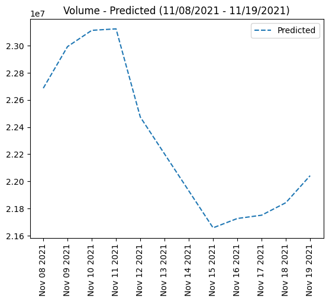

```python
prediction_plot_feature('Volume', predictions, pred_dates)
```

#### GRU

```python
pred_dates = dates_val[:21]
actual_data = df.loc[pred_dates]
predictions = predict_range(gru, pred_dates[0], pred_dates)
```

```
1/1 ━━━━━━━━━━━━━━━━━━━━ 0s 466ms/step
1/1 ━━━━━━━━━━━━━━━━━━━━ 0s 42ms/step
1/1 ━━━━━━━━━━━━━━━━━━━━ 0s 40ms/step
1/1 ━━━━━━━━━━━━━━━━━━━━ 0s 44ms/step
1/1 ━━━━━━━━━━━━━━━━━━━━ 0s 38ms/step
1/1 ━━━━━━━━━━━━━━━━━━━━ 0s 40ms/step
1/1 ━━━━━━━━━━━━━━━━━━━━ 0s 40ms/step
1/1 ━━━━━━━━━━━━━━━━━━━━ 0s 54ms/step
1/1 ━━━━━━━━━━━━━━━━━━━━ 0s 39ms/step
1/1 ━━━━━━━━━━━━━━━━━━━━ 0s 40ms/step
1/1 ━━━━━━━━━━━━━━━━━━━━ 0s 40ms/step
1/1 ━━━━━━━━━━━━━━━━━━━━ 0s 42ms/step
1/1 ━━━━━━━━━━━━━━━━━━━━ 0s 42ms/step
1/1 ━━━━━━━━━━━━━━━━━━━━ 0s 44ms/step
1/1 ━━━━━━━━━━━━━━━━━━━━ 0s 41ms/step
1/1 ━━━━━━━━━━━━━━━━━━━━ 0s 42ms/step
1/1 ━━━━━━━━━━━━━━━━━━━━ 0s 42ms/step
1/1 ━━━━━━━━━━━━━━━━━━━━ 0s 39ms/step
1/1 ━━━━━━━━━━━━━━━━━━━━ 0s 38ms/step
1/1 ━━━━━━━━━━━━━━━━━━━━ 0s 42ms/step
1/1 ━━━━━━━━━━━━━━━━━━━━ 0s 41ms/step
```

```python
evaluate_predictions(actual_data, predictions, df.columns)
```

```
{'Open': {'MAE': 6.881564230887278, 'MSE': 55.33407724902151},
 'High': {'MAE': 7.666761071335569, 'MSE': 65.24157203085906},
 'Low': {'MAE': 7.979554021019345, 'MSE': 73.86303008695549},
 'Close': {'MAE': 7.575417628906249, 'MSE': 65.84137609124816},
 'Volume': {'MAE': 4830961.142857143, 'MSE': 50232768715832.38}}
```

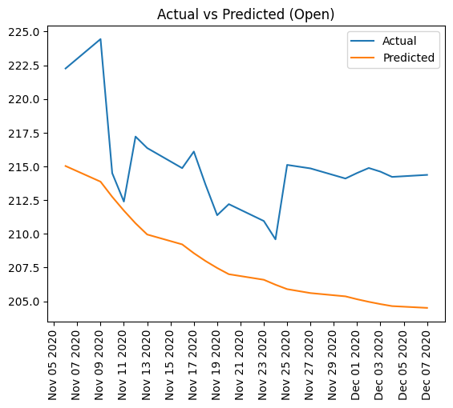

```python
actual_vs_pred_plot_feature('Open', actual_data, predictions, pred_dates)
```

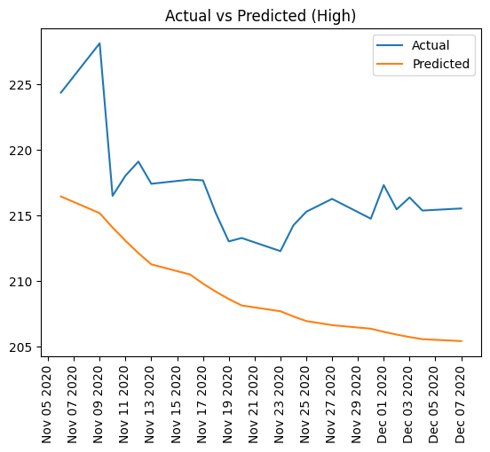

```python
actual_vs_pred_plot_feature('High', actual_data, predictions, pred_dates)
```

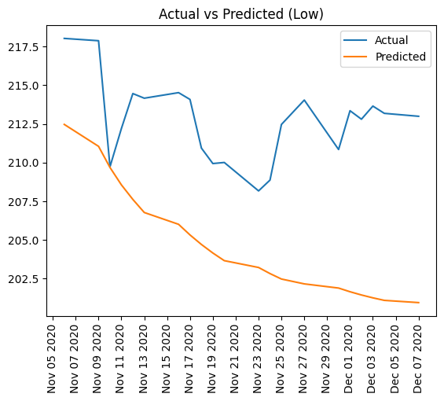

```python
actual_vs_pred_plot_feature('Low', actual_data, predictions, pred_dates)
```

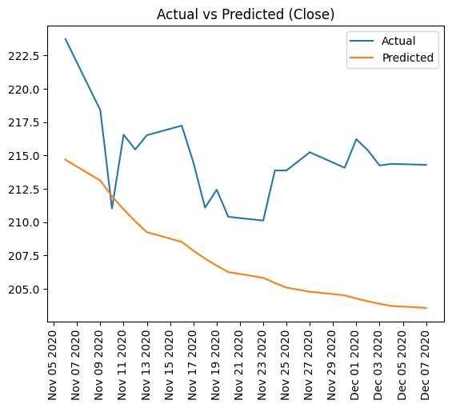

```python
actual_vs_pred_plot_feature('Close', actual_data, predictions, pred_dates)
```

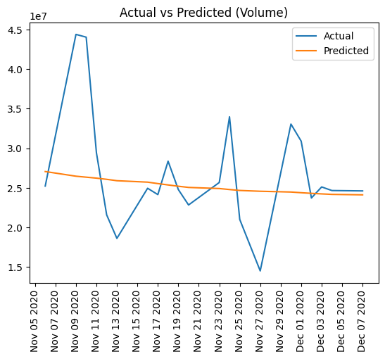

```python
actual_vs_pred_plot_feature('Volume', actual_data, predictions, pred_dates)
```

```python
# Predict all 5 columns for the 10 business days between 11/08/2021 and 11/19/2021
pred_dates = pd.bdate_range(start=df.index.max(), end="2021-11-19")
predictions = predict_range(gru, df.index.max(), pred_dates)
```

```
1/1 ━━━━━━━━━━━━━━━━━━━━ 0s 43ms/step
1/1 ━━━━━━━━━━━━━━━━━━━━ 0s 42ms/step
1/1 ━━━━━━━━━━━━━━━━━━━━ 0s 43ms/step
1/1 ━━━━━━━━━━━━━━━━━━━━ 0s 49ms/step
1/1 ━━━━━━━━━━━━━━━━━━━━ 0s 39ms/step
1/1 ━━━━━━━━━━━━━━━━━━━━ 0s 44ms/step
1/1 ━━━━━━━━━━━━━━━━━━━━ 0s 55ms/step
1/1 ━━━━━━━━━━━━━━━━━━━━ 0s 42ms/step
1/1 ━━━━━━━━━━━━━━━━━━━━ 0s 47ms/step
1/1 ━━━━━━━━━━━━━━━━━━━━ 0s 41ms/step
1/1 ━━━━━━━━━━━━━━━━━━━━ 0s 44ms/step
```

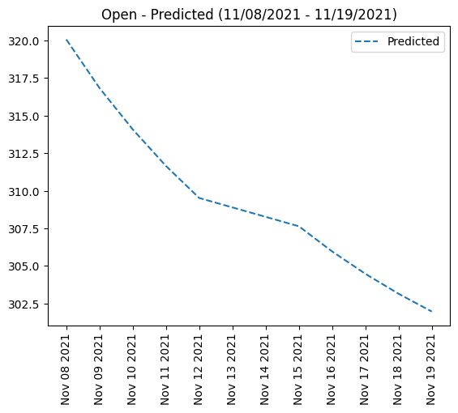

```python
prediction_plot_feature('Open', predictions, pred_dates)
```

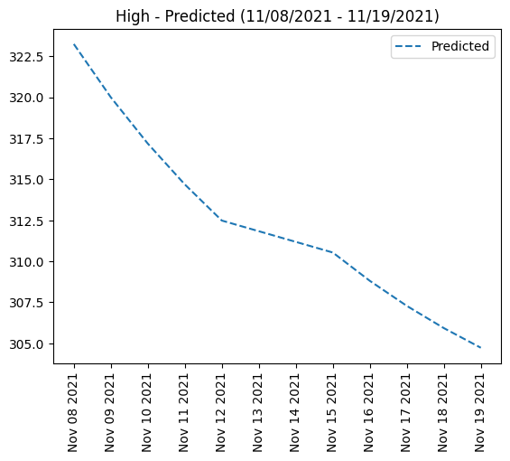

```python
prediction_plot_feature('High', predictions, pred_dates)
```

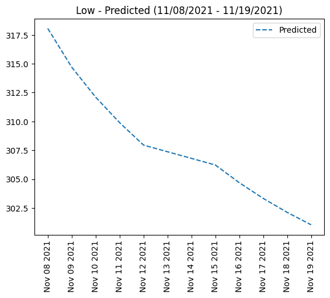

```python
prediction_plot_feature('Low', predictions, pred_dates)
```

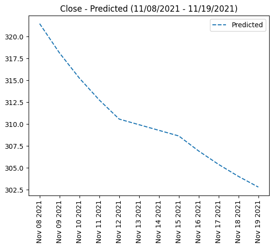

```python
prediction_plot_feature('Close', predictions, pred_dates)
```

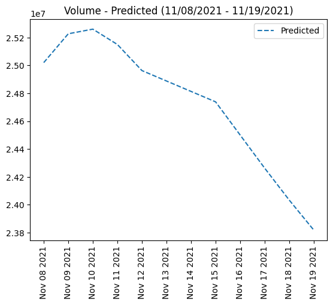

```python
prediction_plot_feature('Volume', predictions, pred_dates)
```

#### LSTM

```python
pred_dates = dates_val[:21]
actual_data = df.loc[pred_dates]
predictions = predict_range(lstm, pred_dates[0], pred_dates)
```

```
1/1 ━━━━━━━━━━━━━━━━━━━━ 0s 462ms/step
1/1 ━━━━━━━━━━━━━━━━━━━━ 0s 40ms/step
1/1 ━━━━━━━━━━━━━━━━━━━━ 0s 39ms/step
1/1 ━━━━━━━━━━━━━━━━━━━━ 0s 45ms/step
1/1 ━━━━━━━━━━━━━━━━━━━━ 0s 41ms/step
1/1 ━━━━━━━━━━━━━━━━━━━━ 0s 41ms/step
1/1 ━━━━━━━━━━━━━━━━━━━━ 0s 42ms/step
1/1 ━━━━━━━━━━━━━━━━━━━━ 0s 100ms/step
1/1 ━━━━━━━━━━━━━━━━━━━━ 0s 56ms/step
1/1 ━━━━━━━━━━━━━━━━━━━━ 0s 59ms/step
1/1 ━━━━━━━━━━━━━━━━━━━━ 0s 64ms/step
1/1 ━━━━━━━━━━━━━━━━━━━━ 0s 55ms/step
1/1 ━━━━━━━━━━━━━━━━━━━━ 0s 58ms/step
1/1 ━━━━━━━━━━━━━━━━━━━━ 0s 63ms/step
1/1 ━━━━━━━━━━━━━━━━━━━━ 0s 85ms/step
1/1 ━━━━━━━━━━━━━━━━━━━━ 0s 65ms/step
1/1 ━━━━━━━━━━━━━━━━━━━━ 0s 90ms/step
1/1 ━━━━━━━━━━━━━━━━━━━━ 0s 61ms/step
1/1 ━━━━━━━━━━━━━━━━━━━━ 0s 63ms/step
1/1 ━━━━━━━━━━━━━━━━━━━━ 0s 56ms/step
1/1 ━━━━━━━━━━━━━━━━━━━━ 0s 58ms/step
```

```python
evaluate_predictions(actual_data, predictions, df.columns)
```

```
{'Open': {'MAE': 3.4424264702845977, 'MSE': 20.552835238917165},
 'High': {'MAE': 3.552838259068081, 'MSE': 24.080635195286494},
 'Low': {'MAE': 3.3434310421316966, 'MSE': 15.945757454620999},
 'Close': {'MAE': 3.554856031249998, 'MSE': 19.811752900856714},
 'Volume': {'MAE': 5426363.80952381, 'MSE': 47949709424449.91}}
```

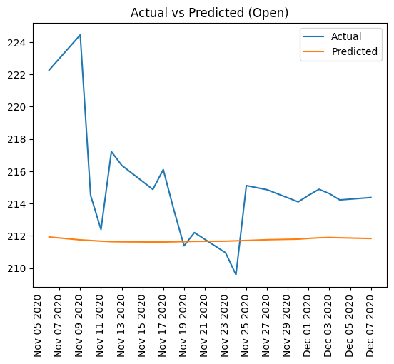

```python
actual_vs_pred_plot_feature('Open', actual_data, predictions, pred_dates)
```

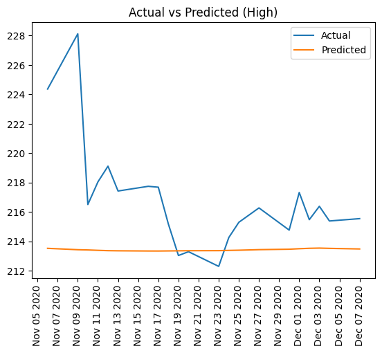

```python
actual_vs_pred_plot_feature('High', actual_data, predictions, pred_dates)
```

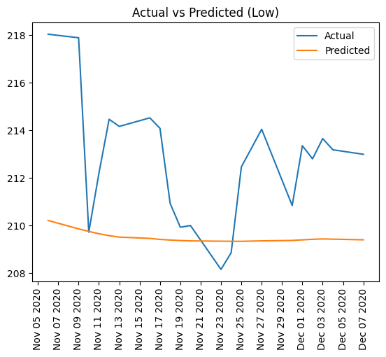

```python
actual_vs_pred_plot_feature('Low', actual_data, predictions, pred_dates)
```

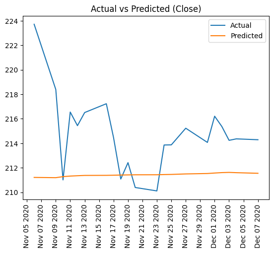

```python
actual_vs_pred_plot_feature('Close', actual_data, predictions, pred_dates)
```

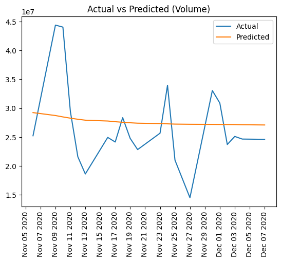

```python
actual_vs_pred_plot_feature('Volume', actual_data, predictions, pred_dates)
```

```python
# Predict all 5 columns for the 10 business days between 11/08/2021 and 11/19/2021
pred_dates = pd.bdate_range(start=df.index.max(), end="2021-11-19")
predictions = predict_range(lstm, df.index.max(), pred_dates)
```

```
1/1 ━━━━━━━━━━━━━━━━━━━━ 0s 40ms/step
1/1 ━━━━━━━━━━━━━━━━━━━━ 0s 41ms/step
1/1 ━━━━━━━━━━━━━━━━━━━━ 0s 57ms/step
1/1 ━━━━━━━━━━━━━━━━━━━━ 0s 40ms/step
1/1 ━━━━━━━━━━━━━━━━━━━━ 0s 39ms/step
1/1 ━━━━━━━━━━━━━━━━━━━━ 0s 41ms/step
1/1 ━━━━━━━━━━━━━━━━━━━━ 0s 39ms/step
1/1 ━━━━━━━━━━━━━━━━━━━━ 0s 41ms/step
1/1 ━━━━━━━━━━━━━━━━━━━━ 0s 39ms/step
1/1 ━━━━━━━━━━━━━━━━━━━━ 0s 39ms/step
1/1 ━━━━━━━━━━━━━━━━━━━━ 0s 38ms/step
```

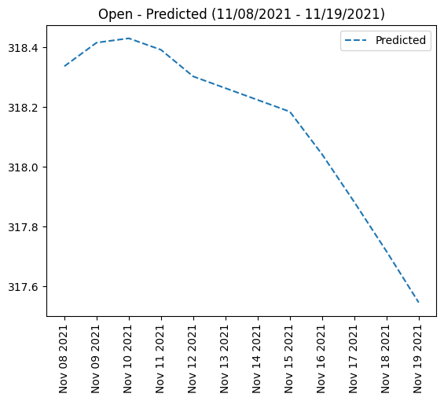

```python
prediction_plot_feature('Open', predictions, pred_dates)
```

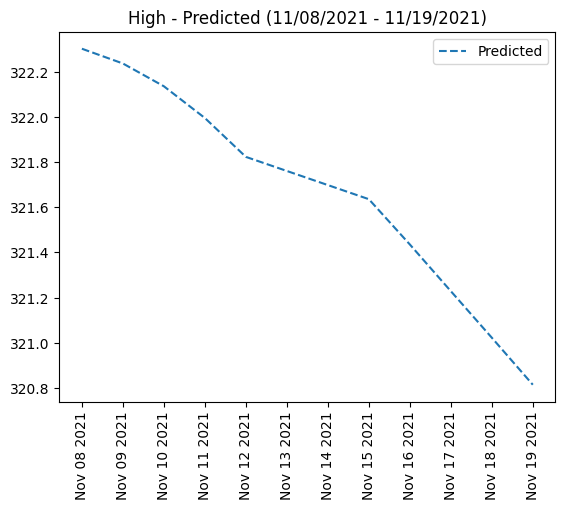

```python
prediction_plot_feature('High', predictions, pred_dates)
```

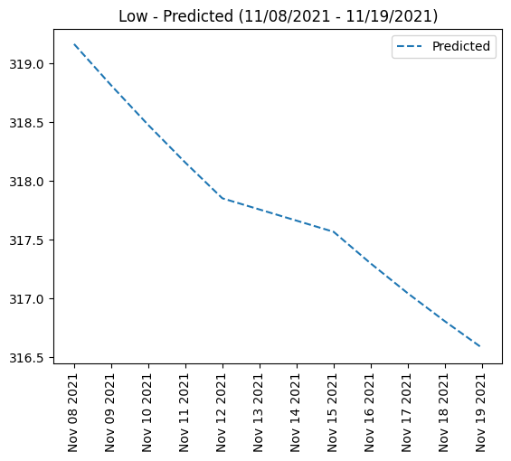

```python
prediction_plot_feature('Low', predictions, pred_dates)
```

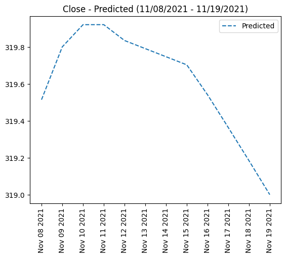

```python
prediction_plot_feature('Close', predictions, pred_dates)
```

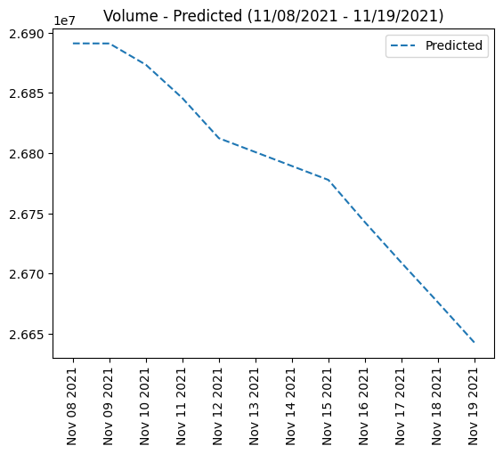

```python
prediction_plot_feature('Volume', predictions, pred_dates)
```

## Findings

In this assignment, I evaluated the LSTM, GRU and SimpleRNN models on their ability to predict the features of the Microsoft Stock price data.

The LSTM model demonstrated the best overall performance across all four price-related features:

Open: MAE = 3.44, MSE = 20.55

High: MAE = 3.55, MSE = 24.08

Low: MAE = 3.34, MSE = 15.95

Close: MAE = 3.55, MSE = 19.81

These low errors indicate strong predictive accuracy and suggest the LSTM effectively predicts the data with minimal error.

The GRU model underperformed on all price features compared to LSTM, with significantly higher errors:

Close: MAE = 7.58, MSE = 65.84

Conclusion:

The LSTM model is the most accurate and reliable for predicting stock prices, with the lowest error rates in every price category. While GRU offers slightly better performance in predicting trading volume, it falls short in pricing accuracy. SimpleRNN does not perform competitively.

```python
!jupyter nbconvert msft_prediction.ipynb --to html
```

```
[NbConvertApp] Converting notebook msft_prediction.ipynb to html
[NbConvertApp] WARNING | Alternative text is missing on 39 image(s).
[NbConvertApp] Writing 2251339 bytes to msft_prediction.html
```